# simple regression model test

robinhwp

2023-01-28

## 단순회귀모형

### 1. 데이터 로드 및 산점도 그림림

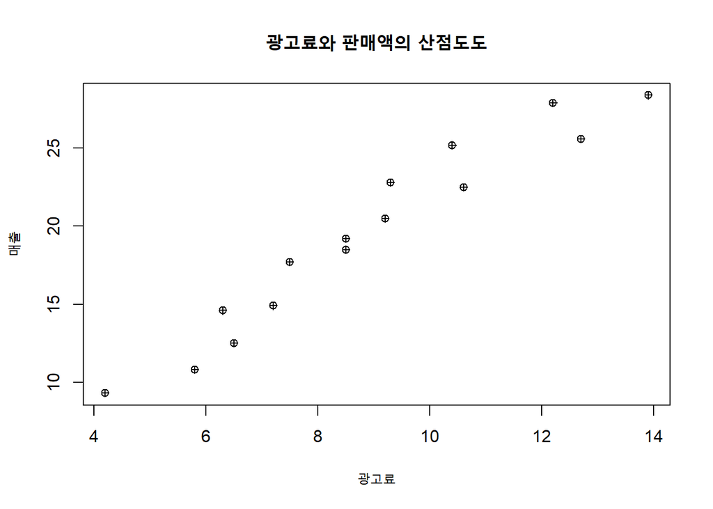

```r
# 데이터 로드 data/market-1.txt
market=read.table("./data/market-1.txt", header = TRUE)
plot(market$X, market$Y, xlab = "광고료", ylab = "매출", main="광고료와 판매액의 산점도도", pch=10)
```

### 2. 회귀직선을 그려본다.

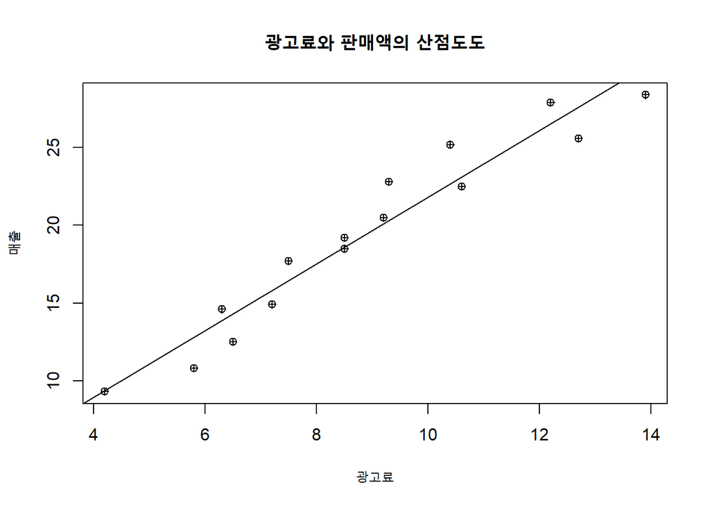

```r
# 산점도가 선형이면 선형회귀 모형을 구한 후 회귀직선을 출력해 본다.
#회귀직선을 그리려면 선형회귀모형을 구해야한다.
market.lm=lm(Y~X, data = market)
plot(market$X, market$Y, xlab = "광고료", ylab = "매출", main="광고료와 판매액의 산점도도", pch=10)
abline(market.lm)
```

### 3. summary 및 분산분석 데이터 생성

```r
# summary
market.lm.summary = summary(market.lm)
market.lm.anova = anova(market.lm)
```

### 4. 추정된 회귀식

```r
# ID   X        Y
#  1  4.2      9.3
#  2  8.5     18.5
#  3  9.3     22.8
#  4  7.5     17.7
#  5  6.3     14.6
#  6 12.2     27.9
#  7  6.5     12.5
#  8 10.4     25.2
#  9  5.8     10.8
# 10  9.2     20.5
# 11  7.2     14.9
# 12  8.5     19.2
# 13 10.6     22.5
# 14 13.9     28.4
# 15 12.7     25.6

b_0=market.lm.summary$coefficients["(Intercept)","Estimate"]
b_1=market.lm.summary$coefficients["X","Estimate"]
paste0("hat_Y=", round(b_0,5), " + ", round(b_1,5), "X")
```

```
## [1] "hat_Y=0.32822 + 2.14967X"
```

${Y}=\beta_0 + \beta_1 X + \varepsilon$ 식의 추정식은 $\hat{Y}=b_0 + b_1 X$

$b_1={\sum_{i=1}^n(X_i-\bar{X})(Y_i -\bar{Y}) \over \sum_{i=1}^n (X_i - \bar{X})^2}$

$b_0= \bar{Y} - b_1 \bar{X}$

### 5. 신뢰구간 구하기

`predict`함수를 이용한 $\hat{Y}와 \hat{Y}_{new}$의 $100(1-\alpha)$% 신뢰구간구간

```r
X=seq(3.5,14.5,0.2)
pred.frame = data.frame(X=X)
# hat_Y의 신뢰구간
pc = predict(market.lm, int="c", newdata = pred.frame)
head(pc)
```

```
##         fit      lwr       upr
## 1  7.852079 5.855247  9.848911
## 2  8.282014 6.344903 10.219125
## 3  8.711949 6.834076 10.589821
## 4  9.141883 7.322721 10.961046
## 5  9.571818 7.810782 11.332854
## 6 10.001753 8.298202 11.705304
```

```r
# hat_Y_new의 신뢰구간간
pp = predict(market.lm, int="p", newdata = pred.frame)
head(pp)
```

```
##         fit      lwr      upr
## 1  7.852079 3.885278 11.81888
## 2  8.282014 4.344937 12.21909
## 3  8.711949 4.803678 12.62022
## 4  9.141883 5.261481 13.02229
## 5  9.571818 5.718324 13.42531
## 6 10.001753 6.174188 13.82932
```

```r
# bar_x와 mse, sxx를 구한다.
bar_x = mean(market$X)
sxx = sum((market$X-bar_x)^2)
mse = market.lm.anova["Residuals", "Mean Sq"]
tval=qt(1-0.05/2, market.lm.anova["Residuals", "Df"])
hat_y.fit=b_0+b_1*X
```

$\hat{Y}$의 신뢰계수 $100(1-\alpha)$% 신뢰구간 ( $\hat{Y} \pm t(n-2;\alpha/2)\sqrt{ MSE[{1\over n} + {(X-\bar{X})^2 \over S_{XX}}]}$

```r
hat_y.pc.lwr=hat_y.fit - tval * sqrt(mse*(1/length(market$X)+(X-bar_x)^2/sxx))
hat_y.pc.upr=hat_y.fit + tval * sqrt(mse*(1/length(market$X)+(X-bar_x)^2/sxx))
hat_y.pc=cbind(hat_y.fit, hat_y.pc.lwr, hat_y.pc.upr)
colnames(hat_y.pc)= c("fit", "lwr", "upr")
head(hat_y.pc)
```

```
##            fit      lwr       upr
## [1,]  7.852079 5.855247  9.848911
## [2,]  8.282014 6.344903 10.219125
## [3,]  8.711949 6.834076 10.589821
## [4,]  9.141883 7.322721 10.961046
## [5,]  9.571818 7.810782 11.332854
## [6,] 10.001753 8.298202 11.705304
```

주어진 X값에서 새로운 예측값 $Y_{new}$의 신뢰구간 $\hat{Y}_{new} \pm t(n-2;\alpha/2) \sqrt{ MSE[1 + {1\over n} + {(X-\bar{X})^2 \over S_{XX}}]}$

```r
hat_y.pp.lwr=hat_y.fit - tval * sqrt(mse*(1+1/length(market$X)+(X-bar_x)^2/sxx))
hat_y.pp.upr=hat_y.fit + tval * sqrt(mse*(1+1/length(market$X)+(X-bar_x)^2/sxx))
hat_y.pp=cbind(hat_y.fit, hat_y.pp.lwr, hat_y.pp.upr)
colnames(hat_y.pp)= c("fit", "lwr", "upr")
head(hat_y.pp)
```

```
##            fit      lwr      upr
## [1,]  7.852079 3.885278 11.81888
## [2,]  8.282014 4.344937 12.21909
## [3,]  8.711949 4.803678 12.62022
## [4,]  9.141883 5.261481 13.02229
## [5,]  9.571818 5.718324 13.42531
## [6,] 10.001753 6.174188 13.82932
```

### 6. 신뢰대 그려보기

- `predict` 결과로 그려보기기

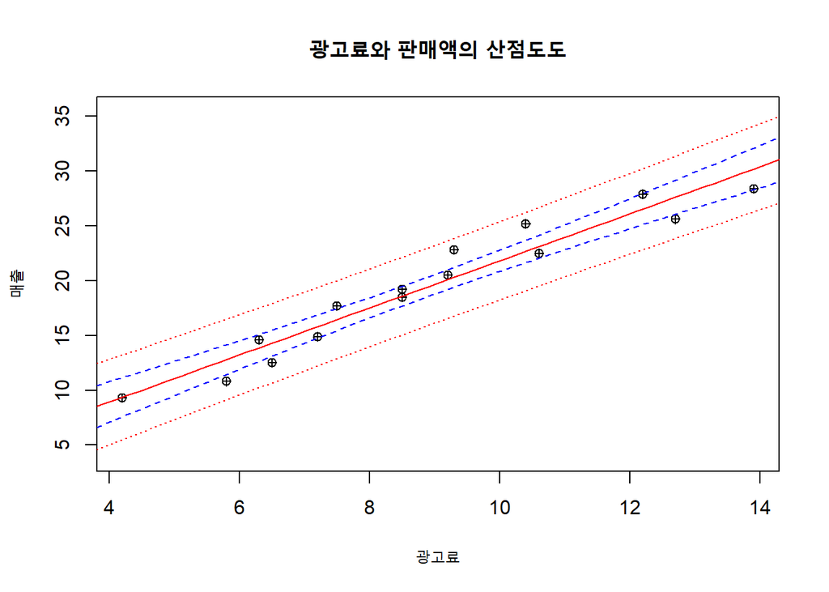

```r
plot(market$X, market$Y, ylim=range(market$Y, pp),xlab = "광고료", ylab = "매출", main="광고료와 판매액의 산점도도", pch=10)

matlines(pred.frame$X, pc, lty=c(1,2,2),col = "BLUE")
matlines(pred.frame$X, pp, lty=c(1,3,3),col = "RED")
```

- 수식 결과로 그려보기

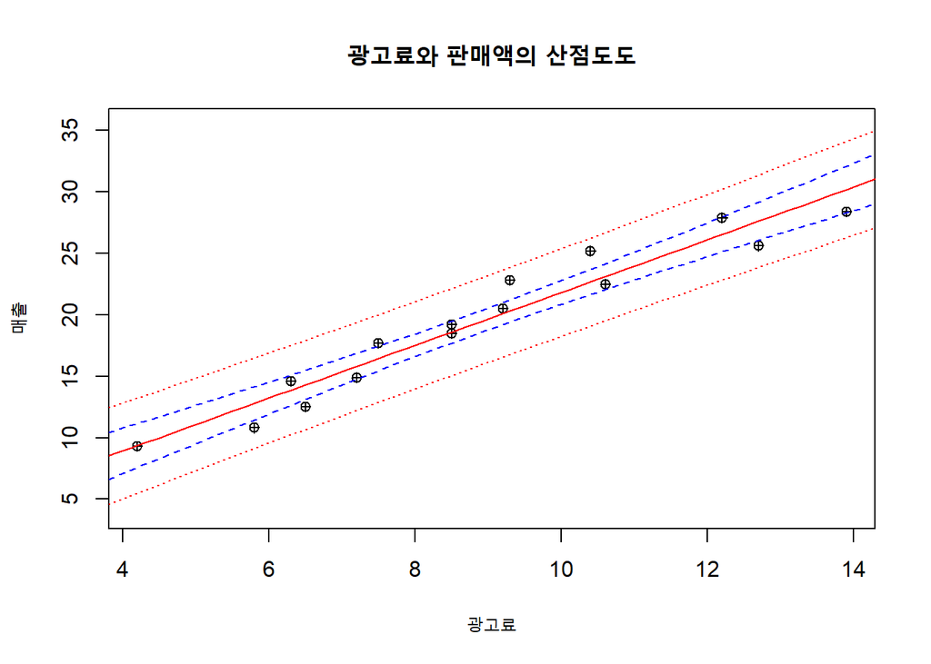

```r
plot(market$X, market$Y, ylim=range(market$Y, pp),xlab = "광고료", ylab = "매출", main="광고료와 판매액의 산점도도", pch=10)

matlines(X, hat_y.pc, lty=c(1,2,2),col = "BLUE")
matlines(X, hat_y.pp, lty=c(1,3,3),col = "RED")
```

### 5. $\beta_1$의 검정

추정된 회귀직선의 기울기 $b_1$ 의 분포는$b_1 \sim N\left( \beta_1, {\sigma^2 \over S_{XX}} \right)$이므로, ${b_1 -\beta_1 \over \sqrt{{MSE\over S_{XX}}}} \sim t(n-2)$를 따른다. 따라서 이를 이용하게 되면 모집단 회귀직선의 기울기 $\beta_1$에 대한 검정이 가능해진다. $\beta_1$의 값이 어떤 특정한 값 $\beta_{10}$이 아닌가 하는 가설을 검정하려면 다음과 같이 귀무가설과 대립가설을 설정한 후 적합된 회귀직선을 이용하여 검정한다.

귀무가설 $H_0: \beta_1 = \beta_{10}$
대립가설 $H_0: \beta_1 \ne \beta_{10}$
위의 가설 통계량은
$$t_0 = {b_1 - \beta_{10}
\over \sqrt{\widehat{Var}(b_1)}} = {b_1-\beta_{10} \over \sqrt{MSE\over
S_{XX}}}$$
이며, 양측검정이므로 $t(n-2;\alpha/2)$인 기각값을 구한 후, 만약 $|t_0| > t(n-2;\alpha/2)$이면 귀무가설을 기각하게 된다.

```r
# t값
( t_0 = summary(market.lm)["coefficients"]$coefficients[2,1]/summary(market.lm)["coefficients"]$coefficients[2,2])
```

```
## [1] 13.88896
```

```r
paste("t_0(", abs(t_0) , ") >  qt:",tval)
```

```
## [1] "t_0( 13.8889629630929 ) >  qt: 2.16036865646279"
```

```r
paste0("p-값=Pr(T>|",t_0,"|)=2X(1-Pr(T<",t_0,"))이므로,",2*(1-pt(t_0,length(market$X)-2)))
```

```
## [1] "p-값=Pr(T>|13.8889629630929|)=2X(1-Pr(T<13.8889629630929))이므로,3.55364715431961e-09"
```

### 6. 가중회귀

```r
x=c(1,2,3,4,5)
y=c(2,3,5,8,7)
w=1/x
w.lm=lm(y~x, weights=w)
summary(w.lm)
```

```
##
## Call:
## lm(formula = y ~ x, weights = w)
##
## Weighted Residuals:
##          1          2          3          4          5
##  8.108e-02 -3.249e-01 -1.076e-16  7.297e-01 -4.835e-01
##
## Coefficients:
##             Estimate Std. Error t value Pr(>|t|)
## (Intercept)   0.3784     0.6891   0.549   0.6212
## x             1.5405     0.2688   5.730   0.0106 *
## ---
## Signif. codes:  0 '***' 0.001 '**' 0.01 '*' 0.05 '.' 0.1 ' ' 1
##
## Residual standard error: 0.5411 on 3 degrees of freedom
## Multiple R-squared:  0.9163, Adjusted R-squared:  0.8884
## F-statistic: 32.84 on 1 and 3 DF,  p-value: 0.01055
```

```r
paste0("가중회귀 직선 방정식 : Y_hat = ", +
        summary(w.lm)["coefficients"]$coefficients[1,1], " + ", +
        summary(w.lm)["coefficients"]$coefficients[2,1],"X", collapse = "\n")
```

```
## [1] "가중회귀 직선 방정식 : Y_hat = 0.378378378378379 + 1.54054054054054X"
```

```r
# 분산분석표표
anova(w.lm)
```

```
## Analysis of Variance Table
##
## Response: y
##           Df Sum Sq Mean Sq F value  Pr(>F)
## x          1 9.6143  9.6143  32.837 0.01055 *
## Residuals  3 0.8784  0.2928
## ---
## Signif. codes:  0 '***' 0.001 '**' 0.01 '*' 0.05 '.' 0.1 ' ' 1
```